# Advanced Categorical Data Analysis - Ordinal and Multinomial Logistic Regression

Mohd Azmi

12/03/2020

# 1 Problem Statements

*note:*

*1. This is short version of full analysis. Refer [Appendix A (link to rpub : https://rpubs.com/puterabemi/CategoryDataAnalysis)](https://rpubs.com/puterabemi/CategoryDataAnalysis) for long version*

*2. The code was hidden, click on the button to view r-code chunk*

## 1.1 Introduction

Type 2 Diabetes Mellitus (T2DM) is a common non-communicable diseases in Malaysia. T2DM is an important risk factor for cardiovascular diseases with various microvascular and macrovascular complications. Currently there is no known cure but the disease can be controlled, enabling the individual to have an improved quality of life.

Malaysian’s Clinical Practice Guidelines - Management of Type 2 Diabetes Mellitus, 5th Edition (2015) outline the main aim of management for T2DM is to reduce acute and chronic complications. In general, all patients with diabetes should undergo lifestyle modification, which consist of dietary therapy and increased physical activity. The need of medication depends on the symptoms, glycaemic control and presence of any complication.

There are several targets for control of T2DM, which consist of glycaemic control, lipid, blood pressure, exercise and body weight targets. For glycaemic control, HbA1c have been used as one of the indicators. Generally, the target for HbA1c was 6.5% or below, however, there was also individulised HbA1c targets according to patients profile, as shown below.

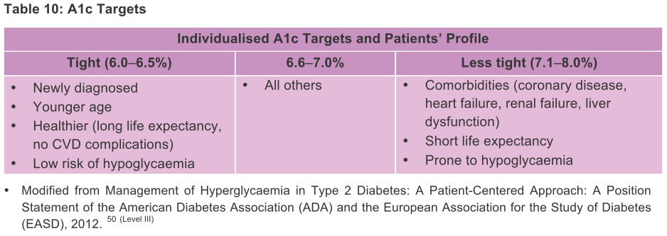

Source: CPG T2DM 2015

## 1.2 Dataset and Objective

This dataset was taken from National Diabetic Registry (NDR), which consist of diabetic patients from Perak. For this exercise, I would like to determine, whether the HbA1c achieved by the patient will fit the patient in which group of the HbA1c target, and what are factors that may associated to the target level.

# 2 Environment

```r
library(pacman)
p_load(readxl, Rmisc, tidyverse, summarytools, qwraps2, broom, knitr, gganimate,
       ordinal, brant, kableExtra, VGAM, generalhoslem, LogisticDx)
options(qwraps2_markup = "markdown")
```

## 2.1 Data Exploration & Data Wrangling

Overview of the dataset

```r
anads0 <- read_csv("dataset.csv", col_types = cols(`Body mass index` = col_skip(),
                                                   X1 = col_skip()))
head(anads0)
```

```
## # A tibble: 6 x 22
##     Age Sex   `Ethnic Group` `Diabetes Age` `Physical Heigh… `Physical Weigh…
##   <dbl> <chr> <chr>                   <dbl>            <dbl>            <dbl>
## 1    90 Fema… Malay                      83              152             49
## 2    83 Male  Chinese                    70              168             66
## 3    80 Male  Chinese                    72              163             69
## 4    80 Male  Malay                      72              159             69.5
## 5    79 Fema… Chinese                    74              152             50
## 6    78 Fema… Chinese                    65              150             65
## # … with 16 more variables: `Physical Waist circumference` <dbl>, HbA1c <dbl>,
## #   `Total Cholesterol` <dbl>, TG <dbl>, HDL <dbl>, LDL <dbl>,
## #   Dyslipidaemia <chr>, Metformin <chr>, Sulphonylureas <chr>,
## #   `Alpha-glucosidase inhibitors` <chr>, Meglitinides <chr>, Glitazones <chr>,
## #   Insulin <chr>, `Centrally Acting` <chr>, Statins <chr>, Fibrates <chr>
```

Data Cleaning

1. remove missing value
2. remove underweight (BMI < 18.5) and very high BMI (BMI >80).
3. select only those with known dylipidaemia status (yes/no)
4. convert HbA1c into the 3 HbA1c target levels
- Target A (HbA1c < 6.6 mmol/l)
- Target B (HbA1c 6.6 - 7.0 mmol/L)
- Target C (HbA1c > 7.0 mmol/L)

```r
anads1 <- anads0 %>%
    mutate(HbA1C_T = cut(HbA1c, breaks = c(0, 6.5, 7.0, 20),
                         labels = c("Target a (< 6.6)", "Target b (6.6 - 7.0)",
                                    "Target c (> 7.0)")),
           HbA1C_Ta = fct_relevel(HbA1C_T, c("Target a (< 6.6)", "Target b (6.6 - 7.0)",
                                             "Target c (> 7.0)")),
           HbA1C_Ta = ordered(HbA1C_Ta, levels = c("Target a (< 6.6)", "Target b (6.6 - 7.0)",
                                                  "Target c (> 7.0)")),
           wt = `Physical Weight`,
           gender = fct_relevel(Sex, c("Female", "Male")),
           dmage = `Diabetes Age`,
           ht = `Physical Height`,
           wc = `Physical Waist circumference`,
           tc = `Total Cholesterol`,
           ethnic = `Ethnic Group`,
           bmi = wt/((ht/100)^2)) %>%
    filter(bmi > 18.499) %>%
    mutate(bmic = cut(bmi, breaks = c(0, 18.499, 22.999, 26.999, 80),
                      labels = c("underweight", "normal", "overweight", "obese")),
           bmic = fct_relevel(bmic, levels = c("underweight", "normal", "overweight", "obese")),
           ethniccol = fct_collapse(ethnic, malay = "Malay", chinese = "Chinese", indian = "Indian",
                                    other = c("Bajau", "Murut", "Orang Asli (Peninsular)",
                                              "Iban", "Foreign National", "Others", "Unknown")),
           ethniccol2 = fct_relevel(ethniccol, c("malay", "chinese", "indian", "other")),
           dyslpd = fct_relevel(Dyslipidaemia, c("no", "yes"))) %>%
    dplyr::select(HbA1c, HbA1C_Ta, Age, gender, ethniccol2, dmage, ht, wt, bmi, bmic, wc,
           tc, dyslpd) %>%
    filter(dyslpd == "yes" | dyslpd == "no") %>%
    drop_na()

str(anads1)
```

```
## Classes 'tbl_df', 'tbl' and 'data.frame':    6055 obs. of  13 variables:
##  $ HbA1c     : num  7 7.5 7.7 13.8 6.9 13.1 6.5 6.7 10 8 ...
##  $ HbA1C_Ta  : Ord.factor w/ 3 levels "Target a (< 6.6)"<..: 2 3 3 3 2 3 1 2 3 3 ...
##  $ Age       : num  90 80 80 75 72 71 70 69 69 68 ...
##  $ gender    : Factor w/ 2 levels "Female","Male": 1 2 2 2 2 1 1 1 2 1 ...
##  $ ethniccol2: Factor w/ 4 levels "malay","chinese",..: 1 2 1 2 2 1 1 3 2 2 ...
##  $ dmage     : num  83 72 72 62 54 57 45 57 66 59 ...
##  $ ht        : num  152 163 159 159 173 160 151 150 157 155 ...
##  $ wt        : num  49 69 69.5 60 85 60 58 61 65 62 ...
##  $ bmi       : num  21.2 26 27.5 23.7 28.4 ...
##  $ bmic      : Factor w/ 4 levels "underweight",..: 2 3 4 3 4 3 3 4 3 3 ...
##  $ wc        : num  88 97 90 97 99 99 97 104 97 87 ...
##  $ tc        : num  4.9 2.9 2.6 3.8 3.1 5.9 4.4 4.7 2.9 4.3 ...
##  $ dyslpd    : Factor w/ 3 levels "no","yes","not known": 2 2 2 2 2 2 2 2 2 2 ...
```

from total 9,457 samples, 3402 samples with missing data, making only 6,055 sample for analysis.

# 3 Descriptive & Exploratory Analysis

## 3.1 Demographic

```r
demo_sum <- list("Age (years)" =
                     list("mean (SD)" = ~ mean_sd(.data$Age, denote_sd = "paren")),
                 "Gender" =
                     list("Male" = ~ n_perc0(.data$gender == "Male"),
                          "Female" = ~ n_perc0(.data$gender == "Female")),
                 "Ethnicity" =
                     list("Malay" = ~ n_perc0(.data$ethniccol2 == "malay"),
                          "Chinese" = ~ n_perc0(.data$ethniccol2 == "chinese"),
                          "Indian" = ~ n_perc0(.data$ethniccol2 == "indian"),
                          "Others" = ~ n_perc0(.data$ethniccol2 == "other")),
                 "Height (cm)" =
                     list("mean (SD)" = ~ mean_sd(.data$ht, denote_sd = "paren")),
                 "Weight (cm)" =
                     list("mean (SD)" = ~ mean_sd(.data$wt, denote_sd = "paren")),
                 "BMI (kg/m^2)" =
                     list("mean (SD)" = ~ mean_sd(.data$bmi, denote_sd = "paren")),
                 "BMI Category" =
                     list("Normal (BMI  18.5 - 22.9)" = ~ n_perc0(.data$bmic == "normal"),
                          "Overweight (BMI 23 - 26.9)" = ~ n_perc0(.data$bmic =="overweight"),
                          "Obese (BMI => 27" = ~ n_perc0(.data$bmic == "obese")),
                 "Waist Circumference (cm)" =
                     list("mean (SD)" = ~ mean_sd(.data$wc, denote_sd = "paren")),
                 "HbA1c (%)" =
                     list("mean (SD)" = ~ mean_sd(.data$HbA1c, denote_sd = "paren")),
                 "HbA1c (Category)" =
                     list("Target A (< 6.6)" = ~ n_perc0(.data$HbA1C_Ta == "Target a (< 6.6)"),
                          "Target B (6.6 - 7.0)" = ~ n_perc0(.data$HbA1C_Ta == "Target b (6.6 - 7.0)"),
                          "Target C (> 7.0)" = ~ n_perc0(.data$HbA1C_Ta == "Target c (> 7.0)")),
                 "Dyslipidaemia" =
                     list("Yes" = ~ n_perc0(.data$dyslpd == "yes"),
                          "No" = ~ n_perc0(.data$dyslpd == "no")))

print(summary_table(anads1, demo_sum), rtitle = "Demographic Summaries", cnames = c("Mean (SD) / n (%)"))
```

```
##
##
## |Demographic Summaries                   |Mean (SD) / n (%) |
## |:---------------------------------------|:-----------------|
## |**Age (years)**                         |&nbsp;&nbsp;      |
## |&nbsp;&nbsp; mean (SD)                  |62.98 (11.04)     |
## |**Gender**                              |&nbsp;&nbsp;      |
## |&nbsp;&nbsp; Male                       |2,338 (39)        |
## |&nbsp;&nbsp; Female                     |3,717 (61)        |
## |**Ethnicity**                           |&nbsp;&nbsp;      |
## |&nbsp;&nbsp; Malay                      |3,437 (57)        |
## |&nbsp;&nbsp; Chinese                    |1,416 (23)        |
## |&nbsp;&nbsp; Indian                     |1,156 (19)        |
## |&nbsp;&nbsp; Others                     |46 (1)            |
## |**Height (cm)**                         |&nbsp;&nbsp;      |
## |&nbsp;&nbsp; mean (SD)                  |157.54 (8.38)     |
## |**Weight (cm)**                         |&nbsp;&nbsp;      |
## |&nbsp;&nbsp; mean (SD)                  |68.09 (13.75)     |
## |**BMI (kg/m^2)**                        |&nbsp;&nbsp;      |
## |&nbsp;&nbsp; mean (SD)                  |27.39 (4.89)      |
## |**BMI Category**                        |&nbsp;&nbsp;      |
## |&nbsp;&nbsp; Normal (BMI  18.5 - 22.9)  |1,079 (18)        |
## |&nbsp;&nbsp; Overweight (BMI 23 - 26.9) |2,074 (34)        |
## |&nbsp;&nbsp; Obese (BMI => 27           |2,902 (48)        |
## |**Waist Circumference (cm)**            |&nbsp;&nbsp;      |
## |&nbsp;&nbsp; mean (SD)                  |93.29 (12.24)     |
## |**HbA1c (%)**                           |&nbsp;&nbsp;      |
## |&nbsp;&nbsp; mean (SD)                  |7.95 (2.11)       |
## |**HbA1c (Category)**                    |&nbsp;&nbsp;      |
## |&nbsp;&nbsp; Target A (< 6.6)           |2,048 (34)        |
## |&nbsp;&nbsp; Target B (6.6 - 7.0)       |620 (10)          |
## |&nbsp;&nbsp; Target C (> 7.0)           |3,387 (56)        |
## |**Dyslipidaemia**                       |&nbsp;&nbsp;      |
## |&nbsp;&nbsp; Yes                        |4,674 (77)        |
## |&nbsp;&nbsp; No                         |1,381 (23)        |
```

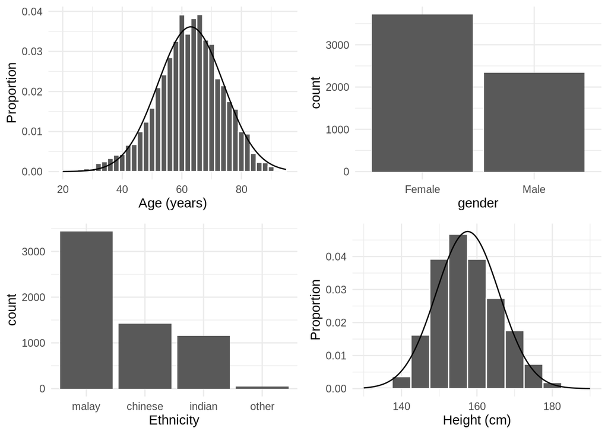

```r
age_plot <- ggplot(anads1, aes(Age)) +
    geom_histogram(aes(y = ..density..), binwidth = 2, colour = "white") +
    stat_function(fun = dnorm, args = list(mean = mean(anads1$Age), sd = sd(anads1$Age))) +
    xlab("Age (years)") + ylab ("Proportion") +
    theme_minimal()

gender_chart <- ggplot(anads1, aes(gender)) +
    geom_bar() + theme_minimal()

ethnic_chart <- ggplot(anads1, aes(ethniccol2)) +
    geom_bar() + xlab("Ethnicity") +
    theme_minimal()

bmi_plot <- ggplot(anads1, aes(bmi)) +
    geom_histogram(aes(y = ..density..), binwidth = 2, colour = "white") +
    stat_function(fun = dnorm, args = list(mean = mean(anads1$bmi), sd = sd(anads1$bmi))) +
    xlim(NA, 45) +
    xlab("BMI (kg/m^2)") + ylab ("Proportion") +
    theme_minimal()

bmic_chart <- ggplot(anads1, aes(bmic)) +
    geom_bar() + xlab("BMI (category)") +
    theme_minimal()

hba1c_plot <- ggplot(anads1, aes(HbA1c)) +
    geom_histogram(aes(y = ..density..), binwidth = .5, colour = "white") +
    stat_function(fun = dnorm, args = list(mean = mean(anads1$HbA1c), sd = sd(anads1$HbA1c))) +
    xlim(NA, 15) +
    xlab("HbA1c (%)") + ylab ("Proportion") +
    theme_minimal()

HbA1CTa_chart <- ggplot(anads1, aes(HbA1C_Ta)) +
    geom_bar() + xlab("Type of Hba1c Target") +
    theme_minimal()

ht_plot <- ggplot(anads1, aes(ht)) +
    geom_histogram(aes(y=..density..), binwidth = 5, colour = "white") +
    stat_function(fun = dnorm, args = list(mean = mean(anads1$ht), sd = sd(anads1$ht))) +
    xlim(130, 190) +
    xlab("Height (cm)") + ylab ("Proportion") +
    theme_minimal()

wt_plot <- ggplot(anads1, aes(wt)) +
    geom_histogram(aes(y=..density..), binwidth = 5, colour = "white") +
    stat_function(fun = dnorm, args = list(mean = mean(anads1$wt), sd = sd(anads1$wt))) +
    xlim(NA, 120) +
    xlab("Weight (kg)") + ylab ("Proportion") +
    theme_minimal()

wc_plot <- ggplot(anads1, aes(wc)) +
    geom_histogram(aes(y=..density..), binwidth = 5, colour = "white") +
    stat_function(fun = dnorm, args = list(mean = mean(anads1$wc), sd = sd(anads1$wc))) +
    xlim(50, 130) +
    xlab("Waist Circumference (cm)") + ylab("Proportion") +
    theme_minimal()

dyslpd_chart <- ggplot(anads1, aes(dyslpd)) +
  geom_bar() + theme_minimal()

multiplot(age_plot, gender_chart, ethnic_chart, ht_plot, layout = matrix(c(1,2,3,4), ncol = 2, byrow = T))
```

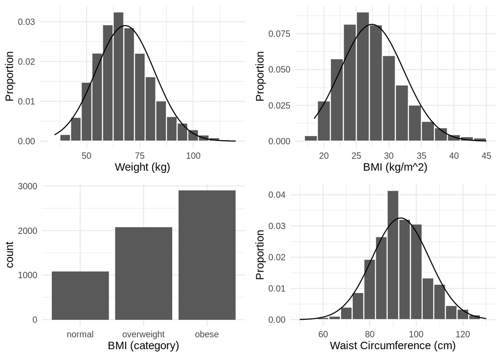

```r
multiplot(wt_plot, bmi_plot, bmic_chart, wc_plot, layout = matrix(c(1,2,3,4), ncol = 2, byrow = T))
```

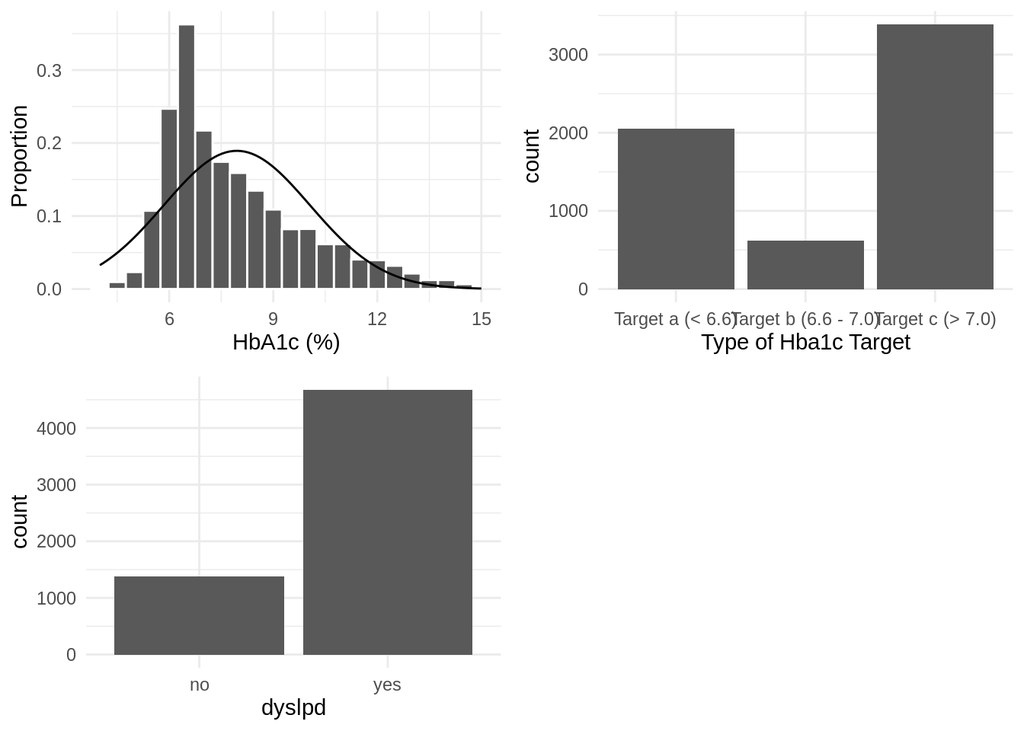

```r
multiplot(hba1c_plot, HbA1CTa_chart, dyslpd_chart, layout = matrix(c(1,2,3,4), ncol = 2, byrow = T))
```

# 4 Ordinal Logistic Regression

To determine which factors (or predictors) that associated with HbA1c target, ordinal logistic regression (cumulative logit model) will be use. The factors include BMI, waist circumference, total cholesterol level, dyslipidaemia status, gender and age.

## 4.1 Univariable Analysis

Univariable analysis was done to determine association between each predictor with HbA1c target.

```r
levels(anads1$HbA1C_Ta)
```

```
## [1] "Target a (< 6.6)"     "Target b (6.6 - 7.0)" "Target c (> 7.0)"
```

Below is example of univariable analysis for BMI (category) and waist circumference (numerical).

### 4.1.1 BMI

Predictor: BMI Category

Simple chart between BMI category and HbA1c Target Level

```r
levels(anads1$bmic)
```

```
## [1] "underweight" "normal"      "overweight"  "obese"
```

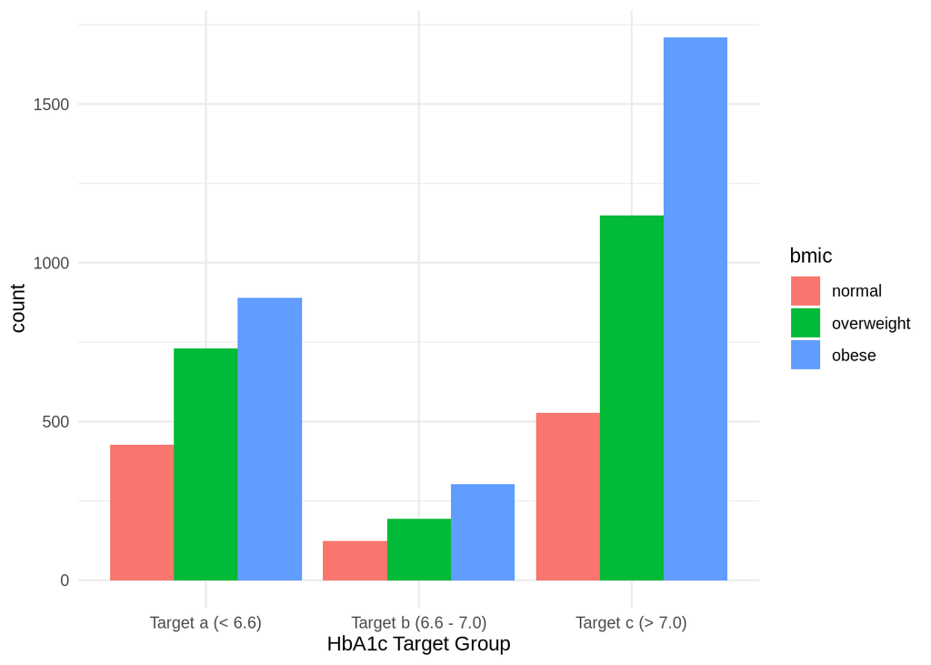

```r
ggplot(anads1, aes(HbA1C_Ta, fill=bmic)) +
  geom_bar(position = position_dodge()) +
  xlab("HbA1c Target Group") + theme_minimal()
```

Univariable Analysis Result

```r
clm_bmic <- clm(HbA1C_Ta ~ bmic, data = anads1)
kable(tidy(clm_bmic, exponentiate = T, conf.int = T), digits = 3, align = "lccccccc")
```

| term | estimate | std.error | statistic | p.value | conf.low | conf.high | coefficient_type |
| --- | --- | --- | --- | --- | --- | --- | --- |
| bmicobese | 1.493 | 0.069 | 5.821 | 0.000 | 1.304 | 1.709 | beta |
| bmicoverweight | 1.263 | 0.072 | 3.230 | 0.001 | 1.096 | 1.456 | beta |
| Target a (< 6.6)\|Target b (6.6 - 7.0) | 0.669 | 0.059 | -6.829 | 0.000 | NA | NA | alpha |
| Target b (6.6 - 7.0)\|Target c (> 7.0) | 1.033 | 0.059 | 0.554 | 0.580 | NA | NA | alpha |

Interpretation:

1. BMI category had association with higher category of HbA1c target group.
2. The odd of overweight BMI being in category of target HbA1c $\leqslant$ 6.5 or above is 1.26 higher (95% CI: 1.10, 1.46, p = 0.001) than a normal BMI.
3. The odd of obese being in category of target HbA1c $\leqslant$ 6.5 or above is 1.49 higher (95% CI: 1.30, 1.71, p < 0.001) than a normal BMI.

### 4.1.2 WC

Predictor: Waist Circumference

Simple chart between waist circumference and HbA1c Target level

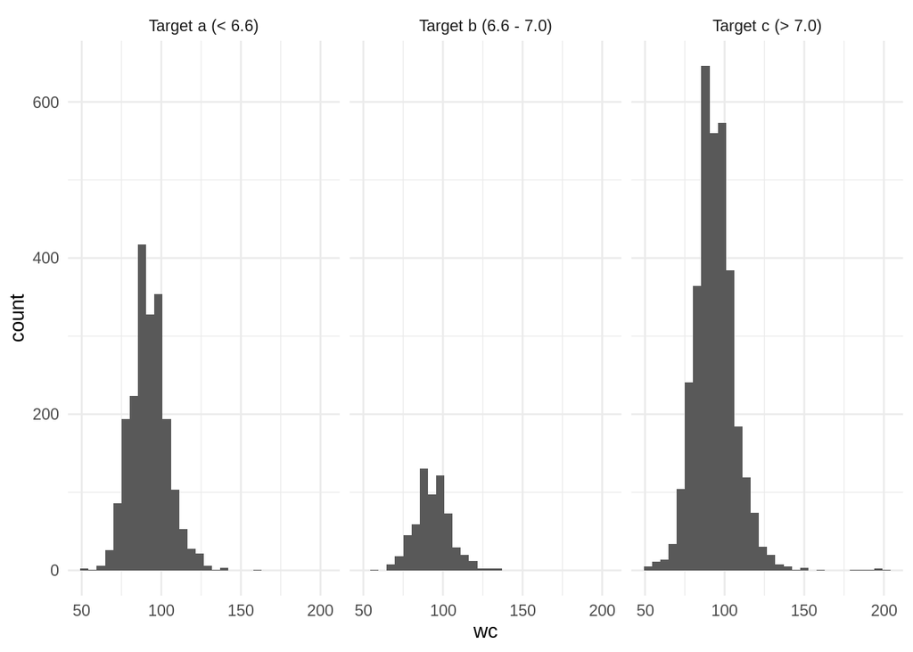

```r
ggplot(anads1, aes(wc)) +
  geom_histogram() + facet_wrap(.~ HbA1C_Ta) +
  theme_minimal()
```

```r
anads1 %>% group_by(HbA1C_Ta) %>%
  summarise(mean = mean(wc), sd = sd(wc)) %>%
  kable(digits = 2, align = "lcc")
```

| HbA1C_Ta | mean | sd |
| --- | --- | --- |
| Target a (< 6.6) | 92.33 | 11.54 |
| Target b (6.6 - 7.0) | 93.44 | 10.97 |
| Target c (> 7.0) | 93.85 | 12.83 |

Univariable Analysis Result

```r
clm_wc <- clm(HbA1C_Ta ~ wc, data = anads1)
kable(tidy(clm_wc, exponentiate = T, conf.int = T), digits = 3, align = "lccccccc")
```

| term | estimate | std.error | statistic | p.value | conf.low | conf.high | coefficient_type |
| --- | --- | --- | --- | --- | --- | --- | --- |
| Target a (< 6.6)\|Target b (6.6 - 7.0) | 1.205 | 0.197 | 0.944 | 0.345 | NA | NA | alpha |
| Target b (6.6 - 7.0)\|Target c (> 7.0) | 1.859 | 0.197 | 3.141 | 0.002 | NA | NA | alpha |
| wc | 1.009 | 0.002 | 4.381 | 0.000 | 1.005 | 1.013 | beta |

Interpretation:

1. Higher waist circumference associates with higher category of HbA1c target group.
2. For each increase of 1 cm of waist circumference, the log odds of being in category of target HbA1c $\leqslant$ 6.5 or above was 0.0092, which correspond increase of odd of 1.0093 times higher.
3. For each increase of 10 cm of waist circumference, the log odds of being in category of target HbA1c $\leqslant$ 6.5 or above was 0.0921, which correspond increase of odd of 1.096 times higher.

Apart from BMI (category) and waist circumference, other variables that have signficant association (p < 0.05) with the outcome in univariable analysis were total cholesterol and age. Other variables that did not have significant association with the outcome in univariable analysis include gender (p = 0.162) and dyslipidaemia status (p = 0.166).

*note: For full univariable analysis, please view the full report at [Appendix A (link to rpub : https://rpubs.com/puterabemi/CategoryDataAnalysis)](https://rpubs.com/puterabemi/CategoryDataAnalysis).*

## 4.2 Multivariable Analysis

For multivariable analysis, several independent variables were identified and included in the preliminary main effect models. All the preliminary main effect models were compared and these variables were included in final model.

1. BMI category
2. Total Cholesterol Level
3. Dyslipidaemia status
4. Gender
5. Age

```r
clm_mod2 <- clm(HbA1C_Ta ~ bmic + tc + dyslpd + gender + Age, data = anads1)
kable(tidy(clm_mod2, exponentiate = T, conf.int = T), digits = 3, align = "lcccc")
```

| term | estimate | std.error | statistic | p.value | conf.low | conf.high | coefficient_type |
| --- | --- | --- | --- | --- | --- | --- | --- |
| Age | 0.970 | 0.002 | -12.086 | 0.000 | 0.966 | 0.975 | beta |
| bmicobese | 1.243 | 0.072 | 3.038 | 0.002 | 1.080 | 1.430 | beta |
| bmicoverweight | 1.159 | 0.074 | 1.989 | 0.047 | 1.002 | 1.339 | beta |
| dyslpdyes | 1.191 | 0.061 | 2.854 | 0.004 | 1.056 | 1.343 | beta |
| genderMale | 1.180 | 0.053 | 3.109 | 0.002 | 1.063 | 1.310 | beta |
| Target a (< 6.6)\|Target b (6.6 - 7.0) | 0.275 | 0.218 | -5.924 | 0.000 | NA | NA | alpha |
| Target b (6.6 - 7.0)\|Target c (> 7.0) | 0.432 | 0.218 | -3.857 | 0.000 | NA | NA | alpha |
| tc | 1.220 | 0.023 | 8.831 | 0.000 | 1.168 | 1.276 | beta |

*note: please refer [Appendix A (link to rpub : https://rpubs.com/puterabemi/CategoryDataAnalysis)](https://rpubs.com/puterabemi/CategoryDataAnalysis) for step-by-step model building*

### 4.2.1 Interaction

There are two interaction that possibly may affect the model, which include

1. gender and total cholesterol level
2. gender and BMI category

Both interactions were tested but not significant.

*note: Please refer [Appendix A (link to rpub : https://rpubs.com/puterabemi/CategoryDataAnalysis)](https://rpubs.com/puterabemi/CategoryDataAnalysis) for interaction testing*

### 4.2.2 Assumption checking - Proportional odds assumption

One of assumption in ordinal logistic regression, which is proportional odds assumption was checked.

```r
nominal_test(clm_mod2)
```

```
## Tests of nominal effects
##
## formula: HbA1C_Ta ~ bmic + tc + dyslpd + gender + Age
##        Df  logLik   AIC     LRT  Pr(>Chi)
## <none>    -5451.1 10918
## bmic    2 -5449.0 10918  4.1013 0.1286495
## tc      1 -5448.5 10915  5.1209 0.0236397 *
## dyslpd  1 -5450.5 10919  1.2256 0.2682630
## gender  1 -5450.6 10919  0.9194 0.3376398
## Age     1 -5445.0 10908 12.1258 0.0004973 ***
## ---
## Signif. codes:  0 '***' 0.001 '**' 0.01 '*' 0.05 '.' 0.1 ' ' 1
```

Interpretation:

1. Proportional odds assumption for total cholesterol level variable was violated.
2. Proportional odds assumption for age variable was violated

Since assumption for proportionality was violated, cholesterol level and age was categorized.

```r
anads2 <- anads1 %>%
  mutate(tcc = cut(tc, breaks = c(0, 5.2, 6.2, 14),
                   labels = c("good", "borderline", "uncontrolled")),
         agec = cut(Age, breaks = c(0,18,50,60,70,100),
                    labels = c("< 18 yo", "19 - 50 yo", "51 - 60 yo", "61 - 70 yo", "above 70 yo")))
```

#### 4.2.2.1 Revised Model

total cholesterol level and age variables was changed to total cholesterol category and age category variable. Below is the revised final ordinal logistic regression.

```r
clm_mod2R <- clm(HbA1C_Ta ~ bmic + tcc + dyslpd + gender + agec, data = anads2)
kable(tidy(clm_mod2R, exponentiate = T, conf.int = T), digits = 3, align = "lcccc")
```

| term | estimate | std.error | statistic | p.value | conf.low | conf.high | coefficient_type |
| --- | --- | --- | --- | --- | --- | --- | --- |
| agec51 - 60 yo | 0.802 | 0.094 | -2.356 | 0.018 | 0.666 | 0.963 | beta |
| agec61 - 70 yo | 0.553 | 0.090 | -6.600 | 0.000 | 0.463 | 0.658 | beta |
| agecabove 70 yo | 0.385 | 0.095 | -10.068 | 0.000 | 0.320 | 0.463 | beta |
| bmicobese | 1.259 | 0.072 | 3.221 | 0.001 | 1.094 | 1.448 | beta |
| bmicoverweight | 1.158 | 0.074 | 1.977 | 0.048 | 1.001 | 1.338 | beta |
| dyslpdyes | 1.169 | 0.061 | 2.542 | 0.011 | 1.036 | 1.319 | beta |
| genderMale | 1.150 | 0.053 | 2.648 | 0.008 | 1.037 | 1.276 | beta |
| Target a (< 6.6)\|Target b (6.6 - 7.0) | 0.475 | 0.109 | -6.829 | 0.000 | NA | NA | alpha |
| Target b (6.6 - 7.0)\|Target c (> 7.0) | 0.746 | 0.109 | -2.696 | 0.007 | NA | NA | alpha |
| tccborderline | 1.385 | 0.068 | 4.799 | 0.000 | 1.213 | 1.583 | beta |
| tccuncontrolled | 1.891 | 0.087 | 7.345 | 0.000 | 1.597 | 2.244 | beta |

# 5 Final Model

In final models, it was found that variables BMI category, total cholesterol level category, dyslipidaemia status, gender and age category were significantly associated with HbA1c target level. Ordinal logistic regression was summarised in table below.

```r
result_clmmod2 <- matrix(c("Intercept 1 (A|B)*", round(coef(clm_mod2R)[1], 3), 0.109,"<0.001","", "", "",
                           "Intercept 2 (B|C)*", round(coef(clm_mod2R)[2], 3), 0.109, 0.007, "", "", "",
                           "Normal", 0, "", "", 1, "", "",
                           "Overweight", round(coef(clm_mod2R)[3], 3), 0.074, 0.048, round(exp(coef(clm_mod2R)[3]), 3), round(exp(confint(clm_mod2R)[1, 1:2]), 3),
                           "Obese", round(coef(clm_mod2R)[4], 3), 0.072, 0.001, round(exp(coef(clm_mod2R)[4]), 3), round(exp(confint(clm_mod2R)[2, 1:2]), 3),
                           "Good", 0, "", "", 1, "", "",
                           "Borderline", round(coef(clm_mod2R)[5], 3), 0.068, "<0.001", round(exp(coef(clm_mod2R)[5]), 3), round(exp(confint(clm_mod2R)[3, 1:2]), 3),
                           "Uncontrolled", round(coef(clm_mod2R)[6], 3), 0.087, "<0.001", round(exp(coef(clm_mod2R)[6]), 3), round(exp(confint(clm_mod2R)[4, 1:2]), 3),
                           "No", 0, "", "", 1, "", "",
                           "Yes", round(coef(clm_mod2R)[7], 3), 0.061, 0.011, round(exp(coef(clm_mod2R)[7]), 3), round(exp(confint(clm_mod2R)[5, 1:2]), 3),
                           "Female", 0, "", "", 1, "", "",
                           "Male", round(coef(clm_mod2R)[8], 3), 0.053, 0.008, round(exp(coef(clm_mod2R)[8]), 3), round(exp(confint(clm_mod2R)[6, 1:2]), 3),
                           "19 - 50 years old", 0, "", "", 1, "", "",
                           "51 - 60 years old", round(coef(clm_mod2R)[9], 3), 0.094, 0.018, round(exp(coef(clm_mod2R)[9]), 3), round(exp(confint(clm_mod2R)[7, 1:2]), 3),
                           "61 - 70 years old", round(coef(clm_mod2R)[10], 3), 0.090, "<0.001", round(exp(coef(clm_mod2R)[10]), 3), round(exp(confint(clm_mod2R)[8, 1:2]), 3),
                           "Above 79 years old", round(coef(clm_mod2R)[11], 3), 0.095, "<0.001", round(exp(coef(clm_mod2R)[11]), 3), round(exp(confint(clm_mod2R)[9, 1:2]), 3)),ncol=7,byrow=TRUE)
colnames(result_clmmod2) <- c("Variables", "Coefficient", "SE", "p-value", "OR", "LL 95% CI", "UL 95% CI")

kable(result_clmmod2, align = "lcccccc") %>%
  kable_styling(bootstrap_options = c("striped", "hover", "condensed")) %>%
  pack_rows("Intercept", 1,2) %>% pack_rows("BMI Category", 3,5) %>%
  pack_rows("TC Category*", 6,8) %>% pack_rows("Dyslipidaemia", 9,10) %>%
  pack_rows("Gender", 11,12) %>% pack_rows("Age Category", 13,16) %>%
  footnote(general = "*Intercept 1: Target A (<= 6.5)|Target B (6.6 - 7.0)\nIntercept 2: Target B (6.6 - 7.0)|Target C (>= 7.1)\nTC: Total Cholesterol Level (Category)\n-Good (<= 5.2 mmol/L)\n-Borderline (5.3 - 6.2 mmol/L)\n-Uncontrolled (>6.2 mmol/L)")
```

[output not shown]

Note:  
*Intercept 1: Target A (<= 6.5)|Target B (6.6 - 7.0) Intercept 2: Target B (6.6 - 7.0)|Target C (>= 7.1) TC: Total Cholesterol Level (Category) -Good (<= 5.2 mmol/L) -Borderline (5.3 - 6.2 mmol/L) -Uncontrolled (>6.2 mmol/L)

# 6 Multinomial Logistic Regression

Another alternative for multiple level outcome analysis if proportional odds assumption was not met is by doing multinomial logistic regression. However multinomial logistic regression will not account for the ordinal level in the outcome.

```r
anads3 <- anads2 %>%
    mutate(HbA1C_Ta2 = cut(HbA1c, breaks = c(0, 6.5, 7.0, 20),
                         labels = c("Target A (< 6.6)", "Target B (6.6 - 7.0)",
                                    "Target C (> 7.0)")),
           HbA1C_Ta3 = fct_relevel(HbA1C_Ta2, levels = c("Target C (> 7.0)", "Target B (6.6 - 7.0)", "Target A (< 6.6)"))) %>%
    dplyr::select(HbA1c, HbA1C_Ta3, HbA1C_Ta2, Age, gender, ethniccol2, dmage, ht, wt, bmi, bmic, wc, tc, dyslpd)
```

## 6.1 Multinomial Logistic Regression Model

The ordinal logistic regression model was reanalyse using multinomial logistic regression with the same variables

```r
levels(anads3$HbA1C_Ta3)
```

```
## [1] "Target C (> 7.0)"     "Target B (6.6 - 7.0)" "Target A (< 6.6)"
```

```r
mulnommod0 <- vglm(HbA1C_Ta3 ~ bmic + tc + dyslpd + gender + Age, multinomial, data = anads3)
summary(mulnommod0)
```

```
##
## Call:
## vglm(formula = HbA1C_Ta3 ~ bmic + tc + dyslpd + gender + Age,
##     family = multinomial, data = anads3)
##
## Pearson residuals:
##                       Min      1Q  Median      3Q   Max
## log(mu[,1]/mu[,3]) -2.426 -1.0258  0.6153  0.8602 1.699
## log(mu[,2]/mu[,3]) -1.010 -0.5947 -0.1401 -0.1081 4.985
##
## Coefficients:
##                   Estimate Std. Error z value Pr(>|z|)
## (Intercept):1     1.128163   0.242544   4.651  3.3e-06 ***
## (Intercept):2    -1.466010   0.399596  -3.669 0.000244 ***
## bmicoverweight:1  0.166401   0.082625   2.014 0.044016 *
## bmicoverweight:2 -0.091554   0.130937  -0.699 0.484412
## bmicobese:1       0.260587   0.080452   3.239 0.001199 **
## bmicobese:2       0.179434   0.124966   1.436 0.151041
## tc:1              0.211042   0.025125   8.400  < 2e-16 ***
## tc:2              0.011486   0.041414   0.277 0.781510
## dyslpdyes:1       0.189030   0.068997   2.740 0.006150 **
## dyslpdyes:2      -0.081703   0.107324  -0.761 0.446491
## genderMale:1      0.190555   0.059659   3.194 0.001403 **
## genderMale:2      0.130813   0.094985   1.377 0.168451
## Age:1            -0.032214   0.002799 -11.511  < 2e-16 ***
## Age:2             0.002711   0.004517   0.600 0.548290
## ---
## Signif. codes:  0 '***' 0.001 '**' 0.01 '*' 0.05 '.' 0.1 ' ' 1
##
## Names of linear predictors: log(mu[,1]/mu[,3]), log(mu[,2]/mu[,3])
##
## Residual deviance: 10875.41 on 12096 degrees of freedom
##
## Log-likelihood: -5437.703 on 12096 degrees of freedom
##
## Number of Fisher scoring iterations: 5
##
## No Hauck-Donner effect found in any of the estimates
##
##
## Reference group is level  3  of the response
```

## 6.2 Model Checking

Model fitness check by assessing logit 1 and logit 2 separately with binary logistic regression

1. Model fitness for Logit 1 model was acceptable with Hosmer Lemeshow not significant and overal percentage = 63.8%, however AUROC was low.
2. Model fitness was acceptable for logit 2 model with Hosmer Lemeshow Test was not significant and overall percentage = 76.8%

*note: Please refer [Appendix A (link to rpub : https://rpubs.com/puterabemi/CategoryDataAnalysis)](https://rpubs.com/puterabemi/CategoryDataAnalysis) for model assessment*

## 6.3 Multinomial Logistic Regression Result

The result of analysis was summarised in table below

```r
result_mulnommod0 <- matrix(c("BMI (Category)", "", "", "", "", "", "", "",
                              "", "Normal", 0, "", "", 1, "", "",
                              "", "Overweight", round(coef(mulnommod0)[3], 3), 0.083, 0.044, round(exp(coef(mulnommod0)[3]), 3), round(exp(confint(mulnommod0)[3, 1:2]), 3),
                              "", "Obese", round(coef(mulnommod0)[5], 3), 0.08045, 0.001, round(exp(coef(mulnommod0)[5]), 3), round(exp(confint(mulnommod0)[5, 1:2]), 3),
                              "TC Level*", "", round(coef(mulnommod0)[7],3), 0.025, "<0.001", round(exp(coef(mulnommod0)[7]), 3), round(exp(confint(mulnommod0)[7, 1:2]), 3),
                              "Dyslipidaemia Status", "", "", "", "", "", "", "",
                              "", "No", 0, "", "", 1, "","",
                              "", "Yes", round(coef(mulnommod0)[9], 3), 0.069, 0.006, round(exp(coef(mulnommod0)[9]), 3), round(exp(confint(mulnommod0)[9, 1:2]), 3),
                              "Gender", "", "", "", "", "", "", "",
                              "", "Female", 0, "", "", 1, "","",
                              "", "Male", round(coef(mulnommod0)[11], 3), 0.0597, 0.001, round(exp(coef(mulnommod0)[11]), 3), round(exp(confint(mulnommod0)[11, 1:2]), 3),
                              "Age (years)", "", round(coef(mulnommod0)[13], 3), 0.003, "<0.001", round(exp(coef(mulnommod0)[13]), 3), round(exp(confint(mulnommod0)[13, 1:2]), 3),
                              "Constant", "", round(coef(mulnommod0)[1],3), 0.243, "<0.001", "", "", "",
                              "BMI (Category)", "", "", "", "", "", "", "",
                              "", "Normal", 0, "", "", 1, "", "",
                              "", "Overweight", round(coef(mulnommod0)[4], 3), 0.131, 0.484, round(exp(coef(mulnommod0)[4]), 3), round(exp(confint(mulnommod0)[4, 1:2]), 3),
                              "", "Obese", round(coef(mulnommod0)[6], 3), 0.125, 0.151, round(exp(coef(mulnommod0)[6]), 3), round(exp(confint(mulnommod0)[6, 1:2]), 3),
                              "TC Level*", "", round(coef(mulnommod0)[8],3), 0.041, 0.782, round(exp(coef(mulnommod0)[8]), 3), round(exp(confint(mulnommod0)[8, 1:2]), 3),
                              "Dyslipidaemia Status", "", "", "", "", "", "", "",
                              "", "No", 0, "", "", 1, "","",
                              "", "Yes", round(coef(mulnommod0)[10], 3), 0.107, 0.446, round(exp(coef(mulnommod0)[10]), 3), round(exp(confint(mulnommod0)[10, 1:2]), 3),
                              "Gender", "", "", "", "", "", "", "",
                              "", "Female", 0, "", "", 1, "","",
                              "", "Male", round(coef(mulnommod0)[12], 3), 0.095, 0.168, round(exp(coef(mulnommod0)[12]), 3), round(exp(confint(mulnommod0)[12, 1:2]), 3),
                              "Age (years)", "", round(coef(mulnommod0)[14],3), 0.005, 0.548, round(exp(coef(mulnommod0)[14]), 3), round(exp(confint(mulnommod0)[14, 1:2]), 3),
                              "Constant", "", round(coef(mulnommod0)[2],3), 0.3996, "<0.001", "", "", ""), ncol = 8, byrow = T)
colnames(result_mulnommod0) <- c("Variables", "", "Coefficient", "SE", "p-value", "RRR", "Lower CI", "Upper CI")
kable(result_mulnommod0, digits = 3, align = "lllcccccc") %>%
    kable_styling(bootstrap_options = c("striped", "hover", "condensed")) %>%
    pack_rows("Logit 1 - [Target C (> 7.0) | Target A (< 6.6)]", 1,13) %>%
    pack_rows("Logit 2 - [Target C (6.6 - 7.0) | Target A (< 6.6)]", 14,26) %>%
    footnote(general = "*TC Level: Total Choleterol Level (mmol/L)")
```

[output not shown]

Note:  
*TC Level: Total Choleterol Level (mmol/L)

# 7 Post-script